# Prediction of phishing URLs — classification problem

### Data Science for Innovation — Assignment 2 (Stage 2)

- Thibaut Barbier
- Julia Lubelska
- Tibere Journel
- Alizée Marchand

Dataset: [PhiUSIIL Phishing URL Dataset (UCI)](https://archive.ics.uci.edu/dataset/967/phiusiil+phishing+url+dataset)

## 1. Setup

```python
import os
import random
import numpy as np
import pandas as pd
import matplotlib.pyplot as plt
import seaborn as sns

from scipy import stats as scipy_stats
from scipy.stats import loguniform, randint, uniform

from sklearn.model_selection import (
    train_test_split,
    GroupShuffleSplit,
    StratifiedKFold,
    RandomizedSearchCV,
)
from sklearn.compose import ColumnTransformer
from sklearn.preprocessing import StandardScaler, OneHotEncoder
from sklearn.pipeline import Pipeline
from sklearn.linear_model import LogisticRegression
from sklearn.ensemble import RandomForestClassifier
from sklearn.inspection import permutation_importance
from sklearn.metrics import (
    precision_score, recall_score, f1_score,
    roc_auc_score, average_precision_score,
    confusion_matrix, ConfusionMatrixDisplay,
)

# Seed
SEED = 42
np.random.seed(SEED)
random.seed(SEED)
```

```python
# ============================================================
# CONFIGURING PATH
# ============================================================
DATA_PATH = os.path.expanduser("/Users/julialubelska/Desktop/DS for Innovation/PhiUSIIL_Phishing_URL_Dataset.csv")
SAVE_DIR  = os.path.expanduser("/Users/julialubelska/Desktop/DS for Innovation/phishing_outputs")
os.makedirs(SAVE_DIR, exist_ok=True)

df = pd.read_csv(DATA_PATH, encoding="utf-8")
df = df.drop(columns=["FILENAME"], errors="ignore")
print("Shape:", df.shape)
df.head()
```

```
Shape: (235795, 55)
```

|  | URL | URLLength | Domain | DomainLength | IsDomainIP | TLD | URLSimilarityIndex | CharContinuationRate | TLDLegitimateProb | URLCharProb | ... | Pay | Crypto | HasCopyrightInfo | NoOfImage | NoOfCSS | NoOfJS | NoOfSelfRef | NoOfEmptyRef | NoOfExternalRef | label |
| --- | --- | --- | --- | --- | --- | --- | --- | --- | --- | --- | --- | --- | --- | --- | --- | --- | --- | --- | --- | --- | --- |
| 0 | https://www.southbankmosaics.com | 31 | www.southbankmosaics.com | 24 | 0 | com | 100.0 | 1.000000 | 0.522907 | 0.061933 | ... | 0 | 0 | 1 | 34 | 20 | 28 | 119 | 0 | 124 | 1 |
| 1 | https://www.uni-mainz.de | 23 | www.uni-mainz.de | 16 | 0 | de | 100.0 | 0.666667 | 0.032650 | 0.050207 | ... | 0 | 0 | 1 | 50 | 9 | 8 | 39 | 0 | 217 | 1 |
| 2 | https://www.voicefmradio.co.uk | 29 | www.voicefmradio.co.uk | 22 | 0 | uk | 100.0 | 0.866667 | 0.028555 | 0.064129 | ... | 0 | 0 | 1 | 10 | 2 | 7 | 42 | 2 | 5 | 1 |
| 3 | https://www.sfnmjournal.com | 26 | www.sfnmjournal.com | 19 | 0 | com | 100.0 | 1.000000 | 0.522907 | 0.057606 | ... | 1 | 1 | 1 | 3 | 27 | 15 | 22 | 1 | 31 | 1 |
| 4 | https://www.rewildingargentina.org | 33 | www.rewildingargentina.org | 26 | 0 | org | 100.0 | 1.000000 | 0.079963 | 0.059441 | ... | 1 | 0 | 1 | 244 | 15 | 34 | 72 | 1 | 85 | 1 |

5 rows × 55 columns

```python
# Sanity checks
print("Missing values per column (first 10 with NaN):")
print(df.isnull().sum().loc[lambda s: s > 0].head(10))
print("\nDuplicates:", df.duplicated().sum())
print("\nClass balance:")
print(df["label"].value_counts(normalize=True).rename({0: "Phishing (0)", 1: "Legitimate (1)"}))
```

```
Missing values per column (first 10 with NaN):
Series([], dtype: int64)

Duplicates: 0

Class balance:
label
Legitimate (1)    0.571895
Phishing (0)      0.428105
Name: proportion, dtype: float64
```

## 2. Exploratory Data Analysis

### 2.1 Outliers (IQR rule)

```python
numeric_cols = df.select_dtypes(include=np.number).drop(columns=["label"])
binary_cols = [c for c in numeric_cols.columns if df[c].nunique() == 2]
numeric_cols = numeric_cols.drop(columns=binary_cols)

outliers_summary = {}
for col in numeric_cols.columns:
    Q1, Q3 = numeric_cols[col].quantile([0.25, 0.75])
    IQR = Q3 - Q1
    lo, hi = Q1 - 1.5 * IQR, Q3 + 1.5 * IQR
    outliers_summary[col] = ((numeric_cols[col] < lo) | (numeric_cols[col] > hi)).sum()

pd.Series(outliers_summary).sort_values(ascending=False).head(15)
```

```
NoOfSubDomain        57389
DegitRatioInURL      51461
NoOfDegitsInURL      51461
NoOfEmptyRef         38885
NoOfiFrame           34441
NoOfExternalRef      22780
URLLength            22493
NoOfLettersInURL     19662
LineOfCode           19280
NoOfImage            18362
NoOfCSS              17906
LargestLineLength    17503
NoOfSelfRef          15576
DomainLength         13474
NoOfPopup            13411
dtype: int64
```

### 2.2 Skewness

```python
skewness = numeric_cols.skew().sort_values(ascending=False)
skewness.head(20)
```

```
NoOfCSS                       464.404031
NoOfObfuscatedChar            204.684335
NoOfJS                        140.435761
NoOfEqualsInURL               114.985479
NoOfEmptyRef                  106.826225
NoOfAmpersandInURL            106.717256
NoOfiFrame                     97.677347
NoOfDegitsInURL                94.877574
NoOfPopup                      84.952694
NoOfExternalRef                65.900247
NoOfSelfRef                    60.381378
NoOfLettersInURL               58.402581
URLLength                      53.321737
LineOfCode                     53.072297
LargestLineLength              48.179926
NoOfOtherSpecialCharsInURL     47.428522
ObfuscationRatio               40.118612
NoOfImage                      28.230253
NoOfQMarkInURL                  8.160618
DegitRatioInURL                 3.244523
dtype: float64
```

### 2.3 Log transformation of highly skewed features

```python
log_features = [
    "NoOfCSS","NoOfObfuscatedChar","NoOfJS","NoOfEqualsInURL",
    "NoOfEmptyRef","NoOfAmpersandInURL","NoOfDegitsInURL",
    "NoOfPopup","NoOfExternalRef","NoOfSelfRef","NoOfLettersInURL",
    "URLLength","LineOfCode","LargestLineLength",
    "NoOfOtherSpecialCharsInURL","NoOfImage",
]

for col in log_features:
    if col in df.columns:
        df[col + "_log"] = np.log1p(df[col])

print("Created", len([c for c in df.columns if c.endswith('_log')]), "log-transformed features.")
```

```
Created 16 log-transformed features.
```

### 2.4 Class balance

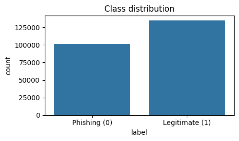

```python
plt.figure(figsize=(5,3))
sns.countplot(x="label", data=df)
plt.xticks([0,1], ["Phishing (0)", "Legitimate (1)"])
plt.title("Class distribution")
plt.tight_layout()
plt.savefig(os.path.join(SAVE_DIR, "class_distribution.png"), dpi=200)
plt.show()
```

### 2.5 Correlation matrix (raw features)

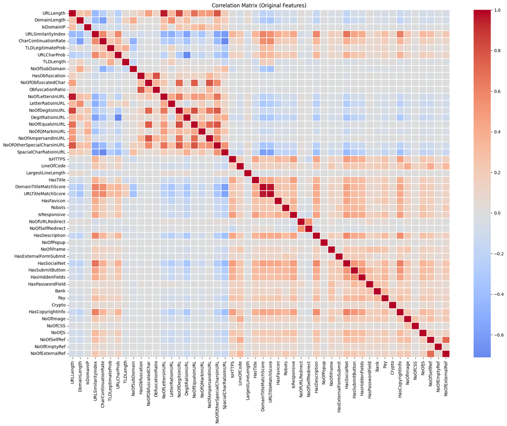

```
DomainTitleMatchScore  URLTitleMatchScore    0.961008
URLLength              NoOfLettersInURL      0.956047
                       NoOfDegitsInURL       0.835809
NoOfDegitsInURL        NoOfEqualsInURL       0.806024
dtype: float64
```

```python
numeric_df = df.select_dtypes(include=np.number).copy()
numeric_df = numeric_df[[c for c in numeric_df.columns if not c.endswith("_log")]]
numeric_df = numeric_df.drop(columns=["label"])

corr = numeric_df.corr()

plt.figure(figsize=(18, 14))
sns.heatmap(corr, cmap="coolwarm", center=0, linewidths=0.3)
plt.title("Correlation Matrix (Original Features)")
plt.tight_layout()
plt.savefig(os.path.join(SAVE_DIR, "correlation_matrix.png"), dpi=200)
plt.show()

# Highly correlated pairs (|r| > 0.8)
threshold = 0.8
high_corr = (
    corr.abs()
    .where(np.triu(np.ones(corr.shape), k=1).astype(bool))
    .stack()
    .sort_values(ascending=False)
)
high_corr[high_corr > threshold]
```

## 3. Leakage diagnostic — single-feature AUC

Before building any model, we measure how well **each individual feature** can classify the target on its own. Any feature with AUC ≥ 0.95 is suspicious: either it is a target leak, or it captures a collection artefact rather than a real-world signal.

```python
y_phish = (df["label"] == 0).astype(int)  # phishing as positive class for diagnostic

skip_cols = ["label", "URL", "Domain", "Title", "TLD"]
single_auc = []
for col in df.columns:
    if col in skip_cols or col.endswith("_log"):
        continue
    try:
        auc = roc_auc_score(y_phish, df[col].astype(float))
        single_auc.append({"feature": col, "auc_abs": max(auc, 1 - auc)})
    except Exception:
        pass

single_auc_df = pd.DataFrame(single_auc).sort_values("auc_abs", ascending=False).reset_index(drop=True)
print("Top 15 single-feature AUC:")
single_auc_df.head(15)
```

```
Top 15 single-feature AUC:
```

|  | feature | auc_abs |
| --- | --- | --- |
| 0 | URLSimilarityIndex | 0.996107 |
| 1 | LineOfCode | 0.990255 |
| 2 | NoOfExternalRef | 0.988021 |
| 3 | NoOfImage | 0.979635 |
| 4 | NoOfSelfRef | 0.972456 |
| 5 | NoOfJS | 0.970823 |
| 6 | NoOfCSS | 0.957596 |
| 7 | HasSocialNet | 0.894747 |
| 8 | HasCopyrightInfo | 0.875450 |
| 9 | HasDescription | 0.846235 |
| 10 | NoOfOtherSpecialCharsInURL | 0.823783 |
| 11 | LargestLineLength | 0.816342 |
| 12 | SpacialCharRatioInURL | 0.807574 |
| 13 | DomainTitleMatchScore | 0.792286 |
| 14 | HasSubmitButton | 0.787992 |

```python
#URLSimilarityIndex check
print("URLSimilarityIndex distribution by class:")
print(df.groupby("label")["URLSimilarityIndex"].describe()[["mean","std","min","max"]].round(3))
print("\nLegitimate URLs with URLSimilarityIndex == 100:",
      (df.loc[df["label"]==1, "URLSimilarityIndex"] == 100).mean() * 100, "%")
print("Phishing URLs with URLSimilarityIndex == 100:",
      (df.loc[df["label"]==0, "URLSimilarityIndex"] == 100).mean() * 100, "%")
```

```
URLSimilarityIndex distribution by class:
          mean     std      min    max
label
0       49.617  22.572    0.156  100.0
1      100.000   0.000  100.000  100.0

Legitimate URLs with URLSimilarityIndex == 100: 100.0 %
Phishing URLs with URLSimilarityIndex == 100: 0.77864183466244 %
```

## 4. Feature configuration

We build **three feature sets** for the ablation study, plus a list of features to drop unconditionally.

[output not shown]

The three configurations differ only in which informative features they include — preprocessing and model hyper-parameter spaces remain identical, so the comparison is fair.

```python
# ---- Features to remove unconditionally ----
target_leak = ["URLSimilarityIndex"]
near_zero_variance = ["IsDomainIP", "HasObfuscation"]
correlated_to_drop = [
    "URLTitleMatchScore",   # keep DomainTitleMatchScore
    "NoOfLettersInURL",     # redundant with URLLength
    "NoOfEqualsInURL",      # redundant with NoOfDegitsInURL
]

# ---- URL-only feature pool ----
url_only_pool = [
    "URLLength","DomainLength","TLDLength","NoOfSubDomain",
    "NoOfDegitsInURL","DegitRatioInURL","NoOfLettersInURL","LetterRatioInURL",
    "NoOfQMarkInURL","NoOfAmpersandInURL","NoOfEqualsInURL",
    "NoOfOtherSpecialCharsInURL","SpacialCharRatioInURL",
    "NoOfObfuscatedChar","ObfuscationRatio",
    "IsHTTPS","TLDLegitimateProb","URLCharProb","CharContinuationRate",
    "TLD",
]

# ---- Configuration B: URL only ----
url_only_features = [c for c in url_only_pool
                     if c not in target_leak + near_zero_variance + correlated_to_drop]

# ---- Configuration C: URL strict ----
url_strict_extra_drop = ["IsHTTPS", "TLDLegitimateProb"]
url_strict_features = [c for c in url_only_features if c not in url_strict_extra_drop]

print("URL-only  features (Config B):", len(url_only_features))
print(" ", url_only_features)
print()
print("URL-strict features (Config C):", len(url_strict_features))
print(" ", url_strict_features)
```

```
URL-only  features (Config B): 18
  ['URLLength', 'DomainLength', 'TLDLength', 'NoOfSubDomain', 'NoOfDegitsInURL', 'DegitRatioInURL', 'LetterRatioInURL', 'NoOfQMarkInURL', 'NoOfAmpersandInURL', 'NoOfOtherSpecialCharsInURL', 'SpacialCharRatioInURL', 'NoOfObfuscatedChar', 'ObfuscationRatio', 'IsHTTPS', 'TLDLegitimateProb', 'URLCharPro…

URL-strict features (Config C): 16
  ['URLLength', 'DomainLength', 'TLDLength', 'NoOfSubDomain', 'NoOfDegitsInURL', 'DegitRatioInURL', 'LetterRatioInURL', 'NoOfQMarkInURL', 'NoOfAmpersandInURL', 'NoOfOtherSpecialCharsInURL', 'SpacialCharRatioInURL', 'NoOfObfuscatedChar', 'ObfuscationRatio', 'URLCharProb', 'CharContinuationRate', 'TLD…
```

```python
# ---- Modelling DataFrame ----
df_model = df.drop(columns=["URL", "Title"], errors="ignore").copy()
df_model = df_model.drop(columns=target_leak + near_zero_variance + correlated_to_drop,
                         errors="ignore")

target = "label"
group_col = "Domain"

y = df_model[target]
groups = df_model[group_col]


X_full = df_model.drop(columns=[target, group_col])

# Configuration A — URL + Webpage
X_urlweb = X_full.copy()

# Configuration B — URL only
X_url = X_full[[c for c in url_only_features if c in X_full.columns]]

# Configuration C — URL strict (no IsHTTPS, no TLDLegitimateProb)
X_url_strict = X_full[[c for c in url_strict_features if c in X_full.columns]]

print("Config A (URL + Webpage) :", X_urlweb.shape)
print("Config B (URL only)      :", X_url.shape)
print("Config C (URL strict)    :", X_url_strict.shape)
```

```
Config A (URL + Webpage) : (235795, 61)
Config B (URL only)      : (235795, 18)
Config C (URL strict)    : (235795, 16)
```

## 5. Train / validation / test splits

For each configuration we generate two split strategies:

- **Stratified** (70 / 15 / 15) — class-balanced, baseline.
- **Domain-based** — `GroupShuffleSplit` on the `Domain` column so that no domain appears in both train and test. This prevents domain memorisation and gives a realistic estimate on unseen domains.

```python
def make_splits(X, y, groups, split_type="stratified", seed=SEED):
    """Return (X_train, X_val, X_test, y_train, y_val, y_test)."""
    if split_type == "stratified":
        X_tr, X_tmp, y_tr, y_tmp = train_test_split(
            X, y, test_size=0.30, stratify=y, random_state=seed
        )
    elif split_type == "domain":
        gss = GroupShuffleSplit(n_splits=1, test_size=0.30, random_state=seed)
        tr_idx, tmp_idx = next(gss.split(X, y, groups=groups))
        X_tr, X_tmp = X.iloc[tr_idx], X.iloc[tmp_idx]
        y_tr, y_tmp = y.iloc[tr_idx], y.iloc[tmp_idx]
    else:
        raise ValueError("split_type must be 'stratified' or 'domain'")

    X_val, X_te, y_val, y_te = train_test_split(
        X_tmp, y_tmp, test_size=0.50, stratify=y_tmp, random_state=seed
    )
    return X_tr, X_val, X_te, y_tr, y_val, y_te
```

```python
# Generate the 6 (config × split) combinations
splits = {}

for cfg_name, X_cfg in [("URL+Web", X_urlweb), ("URL", X_url), ("URL-strict", X_url_strict)]:
    for split_type in ["stratified", "domain"]:
        Xtr, Xv, Xte, ytr, yv, yte = make_splits(X_cfg, y, groups, split_type)
        splits[(cfg_name, split_type)] = {
            "X_train": Xtr, "X_val": Xv, "X_test": Xte,
            "y_train": ytr, "y_val": yv, "y_test": yte,
        }
        print(f"{cfg_name:10s} | {split_type:11s} | "
              f"train={Xtr.shape}, val={Xv.shape}, test={Xte.shape}")
```

[output not shown]

### Model-specific feature versions

Logistic Regression uses log-transformed numeric features; tree models use raw versions.

```python
def split_for_model(split_dict, model_type):
    """
    For LogReg: keep *_log columns, drop their raw counterparts.
    For trees : keep raw columns, drop *_log counterparts.
    """
    X_train = split_dict["X_train"]
    log_cols = [c for c in X_train.columns if c.endswith("_log")]
    raw_cols = [c.replace("_log", "") for c in log_cols
                if c.replace("_log", "") in X_train.columns]

    if model_type == "logreg":
        drop = raw_cols
    else:  # tree
        drop = log_cols

    return {k: (v.drop(columns=drop, errors="ignore")
                if k.startswith("X_") else v)
            for k, v in split_dict.items()}
```

## 6. Preprocessing pipeline

```python
def make_preprocessor(X_train, scale_numeric=False):
    """
    Build a ColumnTransformer adapted to the columns of X_train.
    - 'TLD' (categorical) -> OneHotEncoder
    - binary 0/1 columns  -> passthrough
    - everything else     -> StandardScaler (LR) or passthrough (trees)
    """
    categorical_cols = [c for c in ["TLD"] if c in X_train.columns]
    binary_cols = [c for c in X_train.columns
                   if c not in categorical_cols and X_train[c].nunique() == 2]
    numeric_cols = [c for c in X_train.columns
                    if c not in categorical_cols + binary_cols]

    num_transformer = StandardScaler() if scale_numeric else "passthrough"

    return ColumnTransformer(
        transformers=[
            ("num", num_transformer, numeric_cols),
            ("cat", OneHotEncoder(handle_unknown="ignore"), categorical_cols),
            ("bin", "passthrough", binary_cols),
        ]
    )
```

## 7. Model training and hyperparameter tuning

A single helper trains and tunes each model type with `RandomizedSearchCV` (3-fold StratifiedKFold, scoring='f1', n_iter=5). The same search space is reused across feature configurations and splits, which keeps the comparison fair.

```python
CV = StratifiedKFold(n_splits=3, shuffle=True, random_state=SEED)
N_ITER = 5

PARAM_LR = {"model__C": loguniform(0.01, 10)}

PARAM_RF = {
    "model__n_estimators": randint(50, 200),
    "model__max_depth":    [10, 20, 30, None],
    "model__min_samples_split": randint(2, 15),
    "model__max_features": ["sqrt", "log2"],
}

PARAM_XGB = {
    "model__n_estimators":    randint(50, 200),
    "model__max_depth":       randint(3, 7),
    "model__learning_rate":   uniform(0.03, 0.17),
    "model__subsample":       uniform(0.7, 0.3),
    "model__colsample_bytree":uniform(0.7, 0.3),
}


def tune_model(model_type, X_train, y_train):
    """Return fitted RandomizedSearchCV for the requested model type."""
    if model_type == "logreg":
        preprocessor = make_preprocessor(X_train, scale_numeric=True)
        estimator = LogisticRegression(
            solver="lbfgs", penalty="l2", max_iter=1000, random_state=SEED
        )
        params = PARAM_LR
    elif model_type == "rf":
        preprocessor = make_preprocessor(X_train, scale_numeric=False)
        estimator = RandomForestClassifier(random_state=SEED, n_jobs=1)
        params = PARAM_RF
    elif model_type == "xgb":
        from xgboost import XGBClassifier
        preprocessor = make_preprocessor(X_train, scale_numeric=False)
        estimator = XGBClassifier(
            objective="binary:logistic", eval_metric="logloss",
            random_state=SEED, n_jobs=1,
        )
        params = PARAM_XGB
    else:
        raise ValueError(model_type)

    pipe = Pipeline([("preprocessor", preprocessor), ("model", estimator)])
    search = RandomizedSearchCV(
        pipe, params, n_iter=N_ITER, cv=CV, scoring="f1",
        n_jobs=1, random_state=SEED, verbose=1, error_score="raise",
    )
    search.fit(X_train, y_train)
    return search
```

```python
try:
    import xgboost  # noqa
except ImportError:
    !pip install -q xgboost
```

```python
# ============================================================
# Train every (model × config × split) combination.
# 3 models × 3 configs × 2 splits = 18 trainings.
# Each does 5 iter × 3-fold CV. Total ~270 fits.
# ============================================================
fitted_models = {}
fitted_searches = {}

for cfg_name in ["URL+Web", "URL", "URL-strict"]:
    for split_type in ["stratified", "domain"]:
        for model_type in ["logreg", "rf", "xgb"]:
            data = split_for_model(splits[(cfg_name, split_type)], model_type)
            print(f"\n>>> Tuning {model_type} | {cfg_name} | {split_type}")
            search = tune_model(model_type, data["X_train"], data["y_train"])
            fitted_models[(model_type, cfg_name, split_type)] = search.best_estimator_
            fitted_searches[(model_type, cfg_name, split_type)] = search
            print(f"   best CV F1 = {search.best_score_:.4f} | params = {search.best_params_}")
```

```
>>> Tuning logreg | URL+Web | stratified
Fitting 3 folds for each of 5 candidates, totalling 15 fits
   best CV F1 = 0.9998 | params = {'model__C': np.float64(7.114476009343421)}

>>> Tuning rf | URL+Web | stratified
Fitting 3 folds for each of 5 candidates, totalling 15 fits
   best CV F1 = 0.9996 | params = {'model__max_depth': None, 'model__max_features': 'log2', 'model__min_samples_split': 4, 'model__n_estimators': 199}

>>> Tuning xgb | URL+Web | stratified
Fitting 3 folds for each of 5 candidates, totalling 15 fits
   best CV F1 = 0.9999 | params = {'model__colsample_bytree': np.float64(0.8123620356542087), 'model__learning_rate': np.float64(0.19162143208968577), 'model__max_depth': 5, 'model__n_estimators': 121, 'model__subsample': np.float64(0.8795975452591109)}

>>> Tuning logreg | URL+Web | domain
Fitting 3 folds for each of 5 candidates, totalling 15 fits
   best CV F1 = 0.9999 | params = {'model__C': np.float64(7.114476009343421)}

>>> Tuning rf | URL+Web | domain
Fitting 3 folds for each of 5 candidates, totalling 15 fits
   best CV F1 = 0.9996 | params = {'model__max_depth': None, 'model__max_features': 'log2', 'model__min_samples_split': 4, 'model__n_estimators': 199}

>>> Tuning xgb | URL+Web | domain
Fitting 3 folds for each of 5 candidates, totalling 15 fits
   best CV F1 = 0.9999 | params = {'model__colsample_bytree': np.float64(0.8123620356542087), 'model__learning_rate': np.float64(0.19162143208968577), 'model__max_depth': 5, 'model__n_estimators': 121, 'model__subsample': np.float64(0.8795975452591109)}

>>> Tuning logreg | URL | stratified
Fitting 3 folds for each of 5 candidates, totalling 15 fits
   best CV F1 = 0.9967 | params = {'model__C': np.float64(7.114476009343421)}

>>> Tuning rf | URL | stratified
Fitting 3 folds for each of 5 candidates, totalling 15 fits
   best CV F1 = 0.9968 | params = {'model__max_depth': None, 'model__max_features': 'log2', 'model__min_samples_split': 4, 'model__n_estimators': 199}

>>> Tuning xgb | URL | stratified
Fitting 3 folds for each of 5 candidates, totalling 15 fits
   best CV F1 = 0.9976 | params = {'model__colsample_bytree': np.float64(0.8123620356542087), 'model__learning_rate': np.float64(0.19162143208968577), 'model__max_depth': 5, 'model__n_estimators': 121, 'model__subsample': np.float64(0.8795975452591109)}

>>> Tuning logreg | URL | domain
Fitting 3 folds for each of 5 candidates, totalling 15 fits
   best CV F1 = 0.9967 | params = {'model__C': np.float64(7.114476009343421)}

```

[output cut: 73 more lines]

```
>>> Tuning xgb | URL-strict | stratified
Fitting 3 folds for each of 5 candidates, totalling 15 fits
   best CV F1 = 0.9959 | params = {'model__colsample_bytree': np.float64(0.8123620356542087), 'model__learning_rate': np.float64(0.19162143208968577), 'model__max_depth': 5, 'model__n_estimators': 121, 'model__subsample': np.float64(0.8795975452591109)}

>>> Tuning logreg | URL-strict | domain
Fitting 3 folds for each of 5 candidates, totalling 15 fits
   best CV F1 = 0.9329 | params = {'model__C': np.float64(7.114476009343421)}

>>> Tuning rf | URL-strict | domain
Fitting 3 folds for each of 5 candidates, totalling 15 fits
   best CV F1 = 0.9879 | params = {'model__max_depth': None, 'model__max_features': 'log2', 'model__min_samples_split': 4, 'model__n_estimators': 199}

>>> Tuning xgb | URL-strict | domain
Fitting 3 folds for each of 5 candidates, totalling 15 fits
   best CV F1 = 0.9958 | params = {'model__colsample_bytree': np.float64(0.8123620356542087), 'model__learning_rate': np.float64(0.19162143208968577), 'model__max_depth': 5, 'model__n_estimators': 121, 'model__subsample': np.float64(0.8795975452591109)}
```

## 8. Threshold tuning (phishing as the positive class)

Since the operational target is phishing detection, we tune the classification threshold on the **probability of class 0 (phishing)** to maximise F1 on the validation set.

```python
def tune_threshold_for_phishing(model, X_val, y_val, min_recall=None):
    phishing_idx = list(model.classes_).index(0)
    y_proba = model.predict_proba(X_val)[:, phishing_idx]

    rows = []
    for thr in np.arange(0.05, 0.96, 0.01):
        y_pred = np.where(y_proba >= thr, 0, 1)
        rows.append({
            "threshold": thr,
            "precision_phishing": precision_score(y_val, y_pred, pos_label=0, zero_division=0),
            "recall_phishing":    recall_score(y_val, y_pred, pos_label=0, zero_division=0),
            "f1_phishing":        f1_score(y_val, y_pred, pos_label=0, zero_division=0),
        })
    res = pd.DataFrame(rows)

    if min_recall is None:
        best = res.sort_values("f1_phishing", ascending=False).iloc[0]
    else:
        eligible = res[res["recall_phishing"] >= min_recall]
        best = (eligible.sort_values("f1_phishing", ascending=False).iloc[0]
                if len(eligible) else res.sort_values("recall_phishing", ascending=False).iloc[0])
    return best, res
```

```python
# Tuning threshold for every fitted model
best_thresholds = {}

for (model_type, cfg_name, split_type), model in fitted_models.items():
    data = split_for_model(splits[(cfg_name, split_type)], model_type)
    best_thr, _ = tune_threshold_for_phishing(model, data["X_val"], data["y_val"])
    best_thresholds[(model_type, cfg_name, split_type)] = best_thr
    print(f"{model_type:6s} | {cfg_name:8s} | {split_type:11s} | "
          f"thr={best_thr['threshold']:.2f}, val F1={best_thr['f1_phishing']:.4f}")
```

[output not shown]

## 9. Final test evaluation

```python
def evaluate_model_on_test(model, X_test, y_test, threshold):
    phishing_idx = list(model.classes_).index(0)
    y_proba = model.predict_proba(X_test)[:, phishing_idx]
    y_pred = np.where(y_proba >= threshold, 0, 1)

    metrics = {
        "threshold": threshold,
        "precision_phishing": precision_score(y_test, y_pred, pos_label=0, zero_division=0),
        "recall_phishing":    recall_score(y_test, y_pred, pos_label=0, zero_division=0),
        "f1_phishing":        f1_score(y_test, y_pred, pos_label=0, zero_division=0),
        "roc_auc":             roc_auc_score((y_test == 0).astype(int), y_proba),
        "pr_auc":              average_precision_score((y_test == 0).astype(int), y_proba),
    }
    cm = confusion_matrix(y_test, y_pred, labels=[0, 1])
    return metrics, cm
```

```python
# Evaluating every (model × config × split) on the corresponding test set
results_rows = []
confusion_matrices = {}

for key, model in fitted_models.items():
    model_type, cfg_name, split_type = key
    data = split_for_model(splits[(cfg_name, split_type)], model_type)
    thr = best_thresholds[key]["threshold"]

    metrics, cm = evaluate_model_on_test(model, data["X_test"], data["y_test"], thr)
    metrics.update({"model": model_type, "config": cfg_name, "split": split_type})
    results_rows.append(metrics)
    confusion_matrices[key] = cm

results_df = pd.DataFrame(results_rows)[
    ["model", "config", "split", "threshold",
     "precision_phishing", "recall_phishing", "f1_phishing",
     "roc_auc", "pr_auc"]
].round(4)

results_df.sort_values(["config", "split", "model"]).reset_index(drop=True)
```

|  | model | config | split | threshold | precision_phishing | recall_phishing | f1_phishing | roc_auc | pr_auc |
| --- | --- | --- | --- | --- | --- | --- | --- | --- | --- |
| 0 | logreg | URL | domain | 0.40 | 0.9979 | 0.9940 | 0.9959 | 0.9986 | 0.9989 |
| 1 | rf | URL | domain | 0.65 | 0.9992 | 0.9934 | 0.9963 | 0.9988 | 0.9989 |
| 2 | xgb | URL | domain | 0.41 | 0.9991 | 0.9951 | 0.9971 | 0.9990 | 0.9992 |
| 3 | logreg | URL | stratified | 0.52 | 0.9987 | 0.9935 | 0.9961 | 0.9989 | 0.9990 |
| 4 | rf | URL | stratified | 0.63 | 0.9987 | 0.9941 | 0.9964 | 0.9989 | 0.9989 |
| 5 | xgb | URL | stratified | 0.50 | 0.9993 | 0.9945 | 0.9969 | 0.9991 | 0.9992 |
| 6 | logreg | URL+Web | domain | 0.25 | 0.9999 | 1.0000 | 1.0000 | 1.0000 | 1.0000 |
| 7 | rf | URL+Web | domain | 0.41 | 0.9998 | 0.9997 | 0.9997 | 1.0000 | 1.0000 |
| 8 | xgb | URL+Web | domain | 0.86 | 0.9999 | 0.9999 | 0.9999 | 1.0000 | 1.0000 |
| 9 | logreg | URL+Web | stratified | 0.29 | 0.9999 | 0.9999 | 0.9999 | 1.0000 | 1.0000 |
| 10 | rf | URL+Web | stratified | 0.34 | 0.9994 | 0.9998 | 0.9996 | 1.0000 | 1.0000 |
| 11 | xgb | URL+Web | stratified | 0.50 | 1.0000 | 0.9998 | 0.9999 | 1.0000 | 1.0000 |
| 12 | logreg | URL-strict | domain | 0.31 | 0.9309 | 0.9166 | 0.9237 | 0.9670 | 0.9704 |
| 13 | rf | URL-strict | domain | 0.44 | 0.9848 | 0.9864 | 0.9856 | 0.9985 | 0.9985 |
| 14 | xgb | URL-strict | domain | 0.48 | 0.9964 | 0.9922 | 0.9943 | 0.9988 | 0.9990 |
| 15 | logreg | URL-strict | stratified | 0.32 | 0.9321 | 0.9150 | 0.9235 | 0.9675 | 0.9710 |
| 16 | rf | URL-strict | stratified | 0.43 | 0.9861 | 0.9877 | 0.9869 | 0.9985 | 0.9985 |
| 17 | xgb | URL-strict | stratified | 0.40 | 0.9955 | 0.9946 | 0.9950 | 0.9989 | 0.9991 |

### Confusion matrices

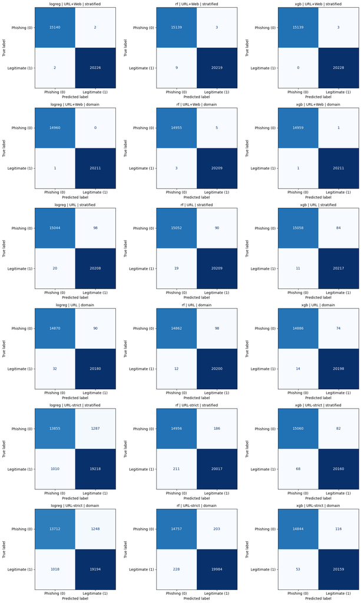

```python
import math
import matplotlib.pyplot as plt
from sklearn.metrics import ConfusionMatrixDisplay

n_cols = 3
n_plots = len(confusion_matrices)
n_rows = math.ceil(n_plots / n_cols)

fig, axes = plt.subplots(n_rows, n_cols, figsize=(15, 4 * n_rows))
axes = axes.flatten()

for ax, (key, cm) in zip(axes, confusion_matrices.items()):
    model_type, cfg_name, split_type = key

    disp = ConfusionMatrixDisplay(
        confusion_matrix=cm,
        display_labels=["Phishing (0)", "Legitimate (1)"]
    )

    disp.plot(ax=ax, cmap="Blues", values_format="d", colorbar=False)
    ax.set_title(f"{model_type} | {cfg_name} | {split_type}", fontsize=10)

for ax in axes[n_plots:]:
    ax.axis("off")

plt.tight_layout()

plt.savefig("confusion_matrices_all.png", dpi=300, bbox_inches="tight")

plt.show()
```

## 10. Robustness analysis — stratified vs domain split

The robustness drop = (stratified F1) − (domain F1) measures how much performance is lost when the model is forced to generalise to unseen domains. A small drop indicates that the model relies on transferable signals rather than domain memorisation.

```python
pivot = results_df.pivot_table(
    index=["model", "config"],
    columns="split",
    values=["f1_phishing", "recall_phishing", "roc_auc", "pr_auc"],
)

# Robustness drop on F1
robustness = pd.DataFrame({
    "f1_stratified": pivot["f1_phishing"]["stratified"],
    "f1_domain":     pivot["f1_phishing"]["domain"],
    "f1_drop":       pivot["f1_phishing"]["stratified"] - pivot["f1_phishing"]["domain"],
    "roc_drop":      pivot["roc_auc"]["stratified"]      - pivot["roc_auc"]["domain"],
    "pr_drop":       pivot["pr_auc"]["stratified"]       - pivot["pr_auc"]["domain"],
}).round(4).sort_values("f1_domain", ascending=False)

robustness
```

| model | config | f1_stratified | f1_domain | f1_drop | roc_drop | pr_drop |
| --- | --- | --- | --- | --- | --- | --- |
| logreg | URL+Web | 0.9999 | 1.0000 | -0.0001 | 0.0000 | 0.0000 |
| xgb | URL+Web | 0.9999 | 0.9999 | 0.0000 | 0.0000 | 0.0000 |
| rf | URL+Web | 0.9996 | 0.9997 | -0.0001 | 0.0000 | 0.0000 |
| xgb | URL | 0.9969 | 0.9971 | -0.0002 | 0.0001 | 0.0000 |
| rf | URL | 0.9964 | 0.9963 | 0.0001 | 0.0001 | 0.0000 |
| logreg | URL | 0.9961 | 0.9959 | 0.0002 | 0.0003 | 0.0001 |
| xgb | URL-strict | 0.9950 | 0.9943 | 0.0007 | 0.0001 | 0.0001 |
| rf | URL-strict | 0.9869 | 0.9856 | 0.0013 | 0.0000 | 0.0000 |
| logreg | URL-strict | 0.9235 | 0.9237 | -0.0002 | 0.0005 | 0.0006 |

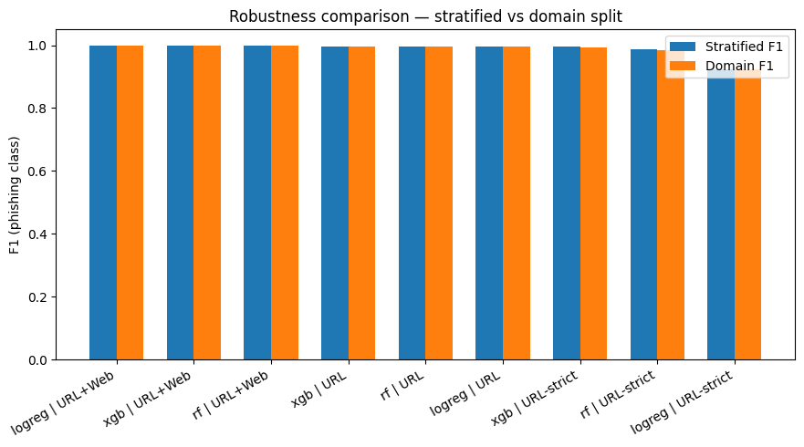

```python
# Visualise robustness drop
fig, ax = plt.subplots(figsize=(9, 5))
plot_df = robustness.reset_index()
plot_df["model_config"] = plot_df["model"] + " | " + plot_df["config"]
x = np.arange(len(plot_df))
w = 0.35
ax.bar(x - w/2, plot_df["f1_stratified"], width=w, label="Stratified F1")
ax.bar(x + w/2, plot_df["f1_domain"],     width=w, label="Domain F1")
ax.set_xticks(x)
ax.set_xticklabels(plot_df["model_config"], rotation=30, ha="right")
ax.set_ylabel("F1 (phishing class)")
ax.set_title("Robustness comparison — stratified vs domain split")
ax.legend()
ax.set_ylim(0, 1.05)
plt.tight_layout()
plt.savefig(os.path.join(SAVE_DIR, "robustness_comparison.png"), dpi=200)
plt.show()
```

## 11. Interpretability

We focus interpretability on the **URL+Webpage / stratified** models, which represent the full feature set. URL-only models can be interpreted analogously by reusing the same code on the corresponding key.

### 11.1 Logistic Regression — standardised coefficients

```python
def get_feature_names_from_preprocessor(preprocessor):
    names = []
    for name, transformer, columns in preprocessor.transformers_:
        if name == "remainder":
            continue
        if name == "cat":
            names.extend(transformer.get_feature_names_out(columns))
        else:
            names.extend(columns)
    return names


lr_model = fitted_models[("logreg", "URL+Web", "stratified")]
lr_pre   = lr_model.named_steps["preprocessor"]
lr_clf   = lr_model.named_steps["model"]

lr_features = get_feature_names_from_preprocessor(lr_pre)
lr_coef = pd.DataFrame({
    "feature": lr_features,
    "coefficient": lr_clf.coef_[0],
}).assign(abs_coef=lambda d: d["coefficient"].abs()).sort_values("abs_coef", ascending=False)

lr_coef.head(20)
```

|  | feature | coefficient | abs_coef |
| --- | --- | --- | --- |
| 673 | IsHTTPS | 10.087391 | 10.087391 |
| 25 | LineOfCode_log | 6.229583 | 6.229583 |
| 7 | LetterRatioInURL | -4.205396 | 4.205396 |
| 26 | LargestLineLength_log | -3.072660 | 3.072660 |
| 22 | NoOfSelfRef_log | 3.022568 | 3.022568 |
| 10 | SpacialCharRatioInURL | -2.710178 | 2.710178 |
| 674 | HasTitle | -2.692248 | 2.692248 |
| 19 | NoOfDegitsInURL_log | -2.357130 | 2.357130 |
| 682 | HasSocialNet | 2.053703 | 2.053703 |
| 28 | NoOfImage_log | 1.968815 | 1.968815 |
| 8 | DegitRatioInURL | -1.921134 | 1.921134 |
| 21 | NoOfExternalRef_log | 1.843239 | 1.843239 |
| 27 | NoOfOtherSpecialCharsInURL_log | -1.746010 | 1.746010 |
| 239 | TLD_com | -1.660572 | 1.660572 |
| 24 | URLLength_log | 1.472235 | 1.472235 |
| 496 | TLD_org | 1.390552 | 1.390552 |
| 680 | HasDescription | 1.380335 | 1.380335 |
| 686 | Bank | -1.373861 | 1.373861 |
| 689 | HasCopyrightInfo | 1.356319 | 1.356319 |
| 5 | NoOfSubDomain | 1.312190 | 1.312190 |

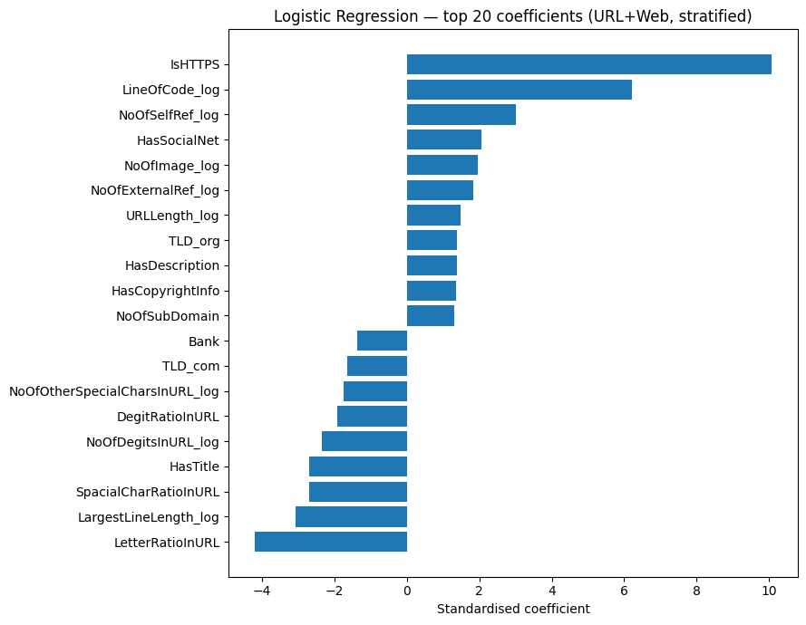

```python
top = lr_coef.head(20).sort_values("coefficient")
plt.figure(figsize=(9, 7))
plt.barh(top["feature"], top["coefficient"])
plt.xlabel("Standardised coefficient")
plt.title("Logistic Regression — top 20 coefficients (URL+Web, stratified)")
plt.tight_layout()
plt.savefig(os.path.join(SAVE_DIR, "lr_coefficients.png"), dpi=200)
plt.show()
```

### 11.2 Random Forest & XGBoost — permutation importance

```python
def plot_permutation_importance(model, X_test, y_test, title, save_name):
    perm = permutation_importance(
        model, X_test, y_test, scoring="f1",
        n_repeats=5, random_state=SEED, n_jobs=1,
    )
    perm_df = pd.DataFrame({
        "feature": X_test.columns,
        "importance_mean": perm.importances_mean,
        "importance_std":  perm.importances_std,
    }).sort_values("importance_mean", ascending=False)

    top = perm_df.head(20).sort_values("importance_mean")
    plt.figure(figsize=(9, 7))
    plt.barh(top["feature"], top["importance_mean"], xerr=top["importance_std"])
    plt.xlabel("Permutation importance (Δ F1)")
    plt.title(title)
    plt.tight_layout()
    plt.savefig(os.path.join(SAVE_DIR, save_name), dpi=200)
    plt.show()
    return perm_df
```

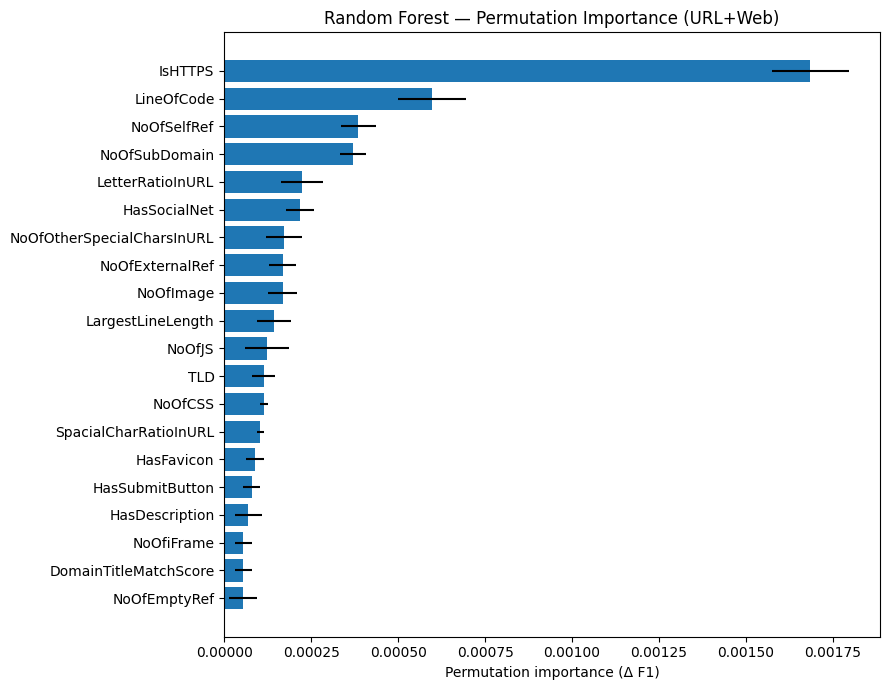

|  | feature | importance_mean | importance_std |
| --- | --- | --- | --- |
| 17 | IsHTTPS | 0.001684 | 0.000111 |
| 18 | LineOfCode | 0.000598 | 0.000098 |
| 42 | NoOfSelfRef | 0.000385 | 0.000051 |
| 7 | NoOfSubDomain | 0.000370 | 0.000038 |
| 10 | LetterRatioInURL | 0.000222 | 0.000061 |
| 31 | HasSocialNet | 0.000217 | 0.000040 |
| 15 | NoOfOtherSpecialCharsInURL | 0.000173 | 0.000052 |
| 44 | NoOfExternalRef | 0.000168 | 0.000040 |
| 39 | NoOfImage | 0.000168 | 0.000042 |
| 19 | LargestLineLength | 0.000143 | 0.000048 |
| 41 | NoOfJS | 0.000123 | 0.000062 |
| 2 | TLD | 0.000114 | 0.000033 |
| 40 | NoOfCSS | 0.000114 | 0.000012 |
| 16 | SpacialCharRatioInURL | 0.000104 | 0.000010 |
| 22 | HasFavicon | 0.000089 | 0.000025 |

```python
rf_model = fitted_models[("rf", "URL+Web", "stratified")]
data = split_for_model(splits[("URL+Web", "stratified")], "rf")
perm_rf_df = plot_permutation_importance(
    rf_model, data["X_test"], data["y_test"],
    "Random Forest — Permutation Importance (URL+Web)",
    "rf_permutation_importance.png",
)
perm_rf_df.head(15)
```

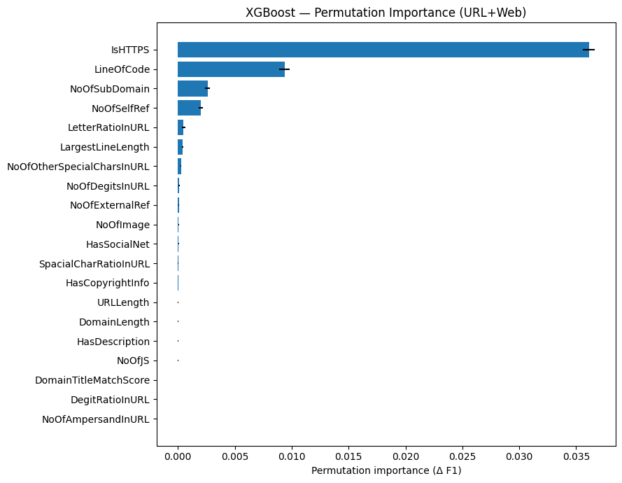

|  | feature | importance_mean | importance_std |
| --- | --- | --- | --- |
| 17 | IsHTTPS | 0.036123 | 0.000519 |
| 18 | LineOfCode | 0.009383 | 0.000461 |
| 7 | NoOfSubDomain | 0.002601 | 0.000199 |
| 42 | NoOfSelfRef | 0.001993 | 0.000187 |
| 10 | LetterRatioInURL | 0.000499 | 0.000134 |
| 19 | LargestLineLength | 0.000425 | 0.000057 |
| 15 | NoOfOtherSpecialCharsInURL | 0.000287 | 0.000034 |
| 11 | NoOfDegitsInURL | 0.000109 | 0.000040 |
| 44 | NoOfExternalRef | 0.000094 | 0.000043 |
| 39 | NoOfImage | 0.000059 | 0.000025 |
| 31 | HasSocialNet | 0.000059 | 0.000034 |
| 16 | SpacialCharRatioInURL | 0.000035 | 0.000020 |
| 38 | HasCopyrightInfo | 0.000030 | 0.000010 |
| 0 | URLLength | 0.000015 | 0.000025 |
| 1 | DomainLength | 0.000010 | 0.000012 |

```python
xgb_model = fitted_models[("xgb", "URL+Web", "stratified")]
data = split_for_model(splits[("URL+Web", "stratified")], "xgb")
perm_xgb_df = plot_permutation_importance(
    xgb_model, data["X_test"], data["y_test"],
    "XGBoost — Permutation Importance (URL+Web)",
    "xgb_permutation_importance.png",
)
perm_xgb_df.head(15)
```

### 11.3 SHAP — XGBoost (URL+Web)

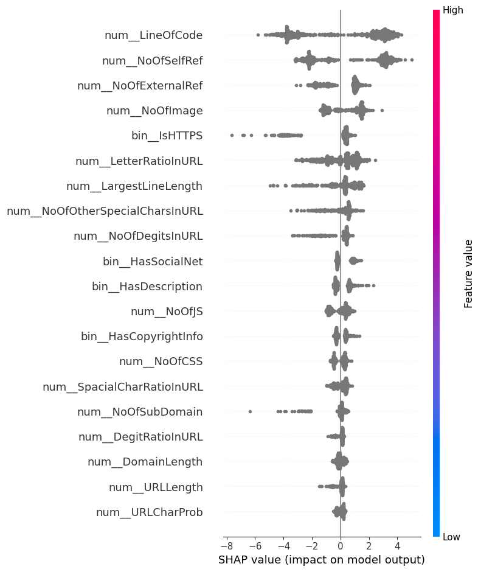

```python
try:
    import shap
except ImportError:
    !pip install -q shap
    import shap

import matplotlib.pyplot as plt
import os

xgb_pipeline = fitted_models[("xgb", "URL+Web", "stratified")]
data = split_for_model(splits[("URL+Web", "stratified")], "xgb")

X_shap_raw = data["X_train"].sample(500, random_state=SEED)
X_shap = xgb_pipeline.named_steps["preprocessor"].transform(X_shap_raw)

explainer = shap.TreeExplainer(xgb_pipeline.named_steps["model"])
shap_values = explainer.shap_values(X_shap)

shap.summary_plot(
    shap_values,
    X_shap,
    feature_names=xgb_pipeline.named_steps["preprocessor"].get_feature_names_out(),
    show=False
)

plt.tight_layout()
plt.savefig(os.path.join(SAVE_DIR, "xgb_shap_summary.png"), dpi=300, bbox_inches="tight")
plt.show()
```

## 12. Final model selection

We rank candidates on:

1. F1 on the **domain split** (closest to deployment conditions)
2. Robustness drop (smaller is better)
3. Interpretability (qualitative — LR > RF ≈ XGB)

```python
interpretability_map = {"logreg": "High", "rf": "Medium", "xgb": "Medium-Low"}

selection = robustness.copy()
selection["interpretability"] = selection.index.get_level_values("model").map(interpretability_map)

def recommendation(row):
    if row["f1_domain"] >= 0.90 and row["f1_drop"] < 0.05:
        return "Strong candidate"
    if row["f1_domain"] >= 0.85:
        return "Good — check robustness"
    return "Lower priority"

selection["recommendation"] = selection.apply(recommendation, axis=1)
selection.sort_values(["f1_domain", "f1_drop"], ascending=[False, True])
```

| model | config | f1_stratified | f1_domain | f1_drop | roc_drop | pr_drop | interpretability | recommendation |
| --- | --- | --- | --- | --- | --- | --- | --- | --- |
| logreg | URL+Web | 0.9999 | 1.0000 | -0.0001 | 0.0000 | 0.0000 | High | Strong candidate |
| xgb | URL+Web | 0.9999 | 0.9999 | 0.0000 | 0.0000 | 0.0000 | Medium-Low | Strong candidate |
| rf | URL+Web | 0.9996 | 0.9997 | -0.0001 | 0.0000 | 0.0000 | Medium | Strong candidate |
| xgb | URL | 0.9969 | 0.9971 | -0.0002 | 0.0001 | 0.0000 | Medium-Low | Strong candidate |
| rf | URL | 0.9964 | 0.9963 | 0.0001 | 0.0001 | 0.0000 | Medium | Strong candidate |
| logreg | URL | 0.9961 | 0.9959 | 0.0002 | 0.0003 | 0.0001 | High | Strong candidate |
| xgb | URL-strict | 0.9950 | 0.9943 | 0.0007 | 0.0001 | 0.0001 | Medium-Low | Strong candidate |
| rf | URL-strict | 0.9869 | 0.9856 | 0.0013 | 0.0000 | 0.0000 | Medium | Strong candidate |
| logreg | URL-strict | 0.9235 | 0.9237 | -0.0002 | 0.0005 | 0.0006 | High | Strong candidate |

## 13. Answering the research questions

The three-configuration ablation gives a clearer picture of what each feature group contributes:

[output not shown]

### Limitations

- **Collection artefact**: webpage features are likely amplified by the fact that phishing pages were crawled while offline or returning empty HTML. We mitigated this by reporting URL-only and URL-strict ablations and domain-based evaluation.
- **Dataset construction biases on URL features**: the PhiUSIIL legitimate set is 100% HTTPS and likely sourced from top-domain rankings; modern phishing increasingly uses HTTPS via Let's Encrypt. Configuration C addresses this by removing `IsHTTPS` and `TLDLegitimateProb`.
- **Single dataset**: results are obtained on PhiUSIIL only; cross-dataset evaluation would strengthen external validity.
- **Threshold sensitivity**: thresholds are tuned on the validation set with F1 as the objective; in production the operational point should be chosen jointly with stakeholders depending on the cost of false negatives versus false positives.